# Word Recall

**Background**

In the dataset below, three groups of people are tested on their ability for word recall:

- SFR, a control group
- Before, an independent intervention group
- Meshed, another independent intervention group

All are independent samples

```r
library(car)
library(tidyverse)
library(pander)
```

## Hypothesis

Where

- $median_1$ refers to the median of the control group
- $median_1$ refers to the median of the intervened group

$$H_0: median_1 - median_2 = \text{0}$$
and
$$H_a: median_1 - median_1 \lt \ \text{0}$$
This means that the null hypothesis indicates that the mean difference between these two groups is not significant and that the alternative hypothesis is that there may be a significant difference between the means of each group.

## Choosing which test to perform

**The following analysis will test to see if all three independent samples are normally distributed.**

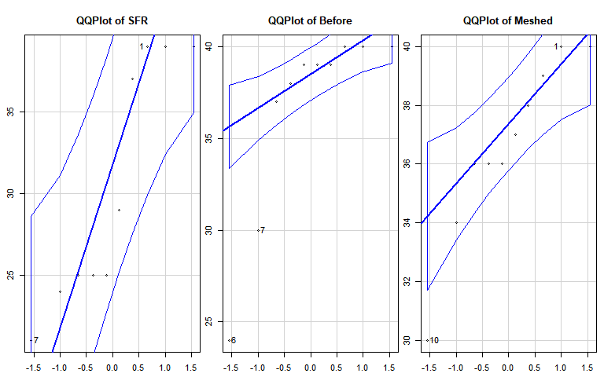

*10* and *1* From the analysis above, there are some data, especially in “Before”, that are not in the normal distribution. Thus, because of the unsurety of the distribution of data, a non-parametric test will be used.

### Using a Wilcoxon Rank Sum (Mann-Whitney) Test

**Bonferroni correction**

Before this test is used, a Bonferroni correction will be calculated to determine a better p-value in order for Type 1 errors for the entire analysis to be minimized to a standard level.

Since two analyses are conducted between the control and both experiment groups, the following calculation will be performed

${\alpha_{adjusted}} = \frac{a}{n}$ where $n$ = the amount of tests are being used

since $n = 2$ and $\alpha = .05$, ${\alpha_{adjusted}} = .025$

```r
friendly2 <- Friendly %>%
  filter(condition %in% c("SFR", "Meshed"))

friendly3 <- Friendly %>%
  filter(condition %in% c("SFR", "Before"))
```

**Mann Whitney test comparing a control to the ‘Meshed’ group**

```r
pander(
  wilcox.test(correct ~ condition,
  data = friendly2,
  alternative = "greater",
  conf.level = (1 - 0.025))
)
```

Wilcoxon rank sum test with continuity correction: `correct` by `condition`

| Test statistic | P value | Alternative hypothesis |
| --- | --- | --- |
| 72 | 0.05075 | greater |

**Mann Whitney test comparing a control to the ‘Before’ group**

```r
pander(
  wilcox.test(correct ~ condition,
  data = friendly3,
  alternative = "greater",
  conf.level = (1 - 0.025))
)
```

Wilcoxon rank sum test with continuity correction: `correct` by `condition`

| Test statistic | P value | Alternative hypothesis |
| --- | --- | --- |
| 76.5 | 0.02278 * | greater |

_Visualizations comparing the ‘meshed’ or ‘before’ group with the control group.__

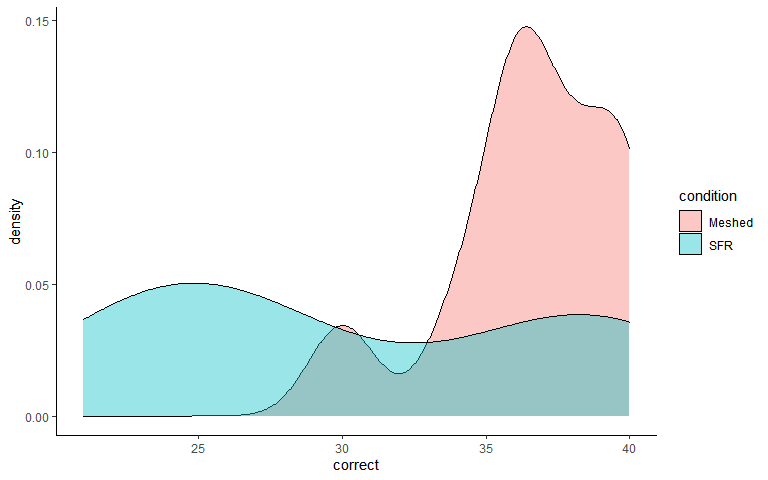

```r
ggplot(friendly2, aes(x = correct, fill = condition)) +
geom_density(alpha = .4) +
  theme_classic()
```

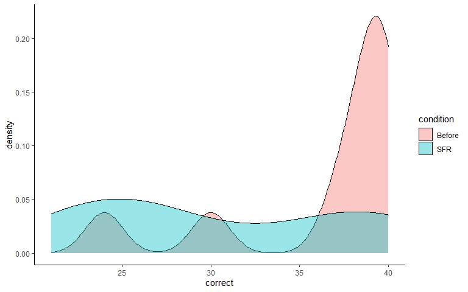

```r
ggplot(friendly3, aes(x = correct, fill = condition)) +
geom_density(alpha = .4) +
  theme_classic()
```

## Conclusion

From the infromation above, we can say that according to the analysis, the ‘Before’ group has better word recall than the ‘SFR’ control group.